# Tres en raya - Clasificación con random forest

- **Víctor Bucheli Guerrero**
- **Universidad del Valle**
- **Mayo 31 / 2018**

# Tic-Tac-Toe Endgame database

**Información relevante al dataset:**

Esta base de datos codifica el conjunto completo de posibles configuraciones de placa al final de los juegos de tres en raya, donde se supone que jugó “x” primero. El concepto objetivo es “ganar para o” (es decir, positiva cuando “o” tiene uno de 8 maneras posibles de crear un “tres en raya”).

Número de instancias: 958 (tableros legales de final de tres en raya)

Número de atributos: 9, cada uno correspondiente a un cuadrado de tres en raya

Informacion de los atributos: (x=player x has taken, o=player o has taken, b=blank)

```
1. top-left-square: {x,o,b}
2. top-middle-square: {x,o,b}
3. top-right-square: {x,o,b}
4. middle-left-square: {x,o,b}
5. middle-middle-square: {x,o,b}
6. middle-right-square: {x,o,b}
7. bottom-left-square: {x,o,b}
8. bottom-middle-square: {x,o,b}
9. bottom-right-square: {x,o,b}
10. Class: {1,0}
```

Para la clase 0 (positiva), siginfica que gana el jugador 0 (pierde x)

Para la clase 1 (negativa), siginfica que gana el jugador x (pierde 0)

## Carga de datos

```r
#Cargamos el dataset
tictactoe.dataset = read.csv("tictactoe.csv")
# Asignamos los nombres de las columnas
colnames(tictactoe.dataset) <- c("tls","tms","trs","mls", "mms", "mrs", "bls", "bms", "brs", "clase")
#volvemos categorico la columna "clase"
tictactoe.dataset[, "clase"] <-as.factor(tictactoe.dataset[, "clase"])
```

## Partir los datos en el conjunto de entrenamiento y de pruebas

Para el conjunto de entrenamiento se va a extraer el 70% de los datos de tictactoe.dataset, el otro 30% se va a usar para el conjunto de pruebas, se inicializa en la misma semilla para hacer el experimento reproducible.

```r
set.seed(1234) # semilla
muestra.cantidad <- floor(0.7 * nrow(tictactoe.dataset))
entrenamiento.index <- sample(seq_len(nrow(tictactoe.dataset)), size = muestra.cantidad)
conjunto_entrenamiento <- tictactoe.dataset[entrenamiento.index, ]
conjunto_prueba <- tictactoe.dataset[- entrenamiento.index, ]
```

## Entrenamiento

En el siguiente código, formula especifica que **clase** es la variable objetivo y todas las demás variables son variables **independientes**.

Esto siginfica que el clasificador va a intentar predecir la clase objetivo (0 gana o, 1 pierde O) utilizando los otros atributos tls, tms, trs, mls, mms, mrs, bls, bms, brs

```r
library(randomForest)
formula <- clase ~ tls + tms + trs + mls + mms + mrs + bls + bms + brs
rf <- randomForest(formula, data=conjunto_entrenamiento, ntree=100, proximity=TRUE)
# Verificamos la predicción (notemos que lo hacemos con el conjunto de entrenamiento)
prediccion <- predict(rf)
table(prediccion, conjunto_entrenamiento[, "clase"])
```

```
prediccion   0   1
         0 204   8
         1  21 436
```

## Pruebas

Ahora creemos la matriz de confusión probando el modelo con el conjunto de pruebas y saquemos algunas conclusiones:

[output not shown]

```r
testPred_tictactoe_rf <- predict(rf, newdata = conjunto_prueba)
table(testPred_tictactoe_rf, conjunto_prueba[, "clase"])
```

```
testPred_tictactoe_rf   0   1
                    0 102   1
                    1   5 180
```

## Desempeño con curva de ROC

La curva de ROC nos proporciona una medida de desempeño de nuestro clasificador, entre mas cercana el area bajo la curva de ROC sea a 1, mejor es nuestro clasificador.

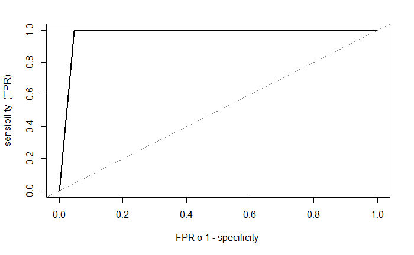

```r
library(ROCR)
roc_pred <- prediction(as.numeric(testPred_tictactoe_rf), as.numeric(conjunto_prueba[, "clase"]))
perf <-performance(roc_pred, measure="tpr", x.measure="fpr")
plot(perf, lwd=2, xlab="FPR o 1 - specificity ",
 ylab="sensibility  (TPR)")
abline(a=0, b=1, col="gray50", lty=3) #Dibujamos la diagonal
```

## AUC - Area bajo la curva ROC

```r
auc <- performance(roc_pred, "auc")
auc <- unlist(slot(auc, "y.values"))
auc
```

```
[1] 0.9738731
```